# Case Study: Smart Reply Implemented as Nueral Question Answer

### 4.1 Encoding

**1. Qustion**

```python
train_clean_question_sequence = token.texts_to_sequences(train["clean_question"].values)
print(type(train_clean_question_sequence))

dev_clean_question_sequence = token.texts_to_sequences(dev["clean_question"].values)
print(type(dev_clean_question_sequence))

cv_clean_question_sequence = token.texts_to_sequences(cv["clean_question"].values)
print(type(cv_clean_question_sequence))
```

```
<class 'list'>
<class 'list'>
<class 'list'>
```

```python
# padding sequences
from keras.preprocessing.sequence import pad_sequences
```

```python
train_question_sequence = pad_sequences(train_clean_question_sequence,maxlen=QUES_LEN,padding="post")


print("Max Question Sequence length is {}".format(train_question_sequence.shape[1]))

cv_question_sequence = pad_sequences(cv_clean_question_sequence,maxlen=QUES_LEN,padding="post")
dev_question_sequence = pad_sequences(dev_clean_question_sequence,maxlen=QUES_LEN,padding="post")

print(train_question_sequence.shape)
print(cv_question_sequence.shape)
print(dev_question_sequence.shape)
```

```
Max Question Sequence length is 40
(30000, 40)
(10000, 40)
(10000, 40)
```

**2. Context**

```python
train_clean_context_sequence = token.texts_to_sequences(train["clean_context"].values)
print(type(train_clean_context_sequence))

dev_clean_context_sequence = token.texts_to_sequences(dev["clean_context"].values)
print(type(dev_clean_context_sequence))

cv_clean_context_sequence = token.texts_to_sequences(cv["clean_context"].values)
print(type(cv_clean_context_sequence))
```

```
<class 'list'>
<class 'list'>
<class 'list'>
```

```python
train_context_sequence = pad_sequences(train_clean_context_sequence,maxlen=CON_LEN)

# fix this value as results may vary during various runs

print("Max context Sequence length is {}".format(train_context_sequence.shape[1]))

cv_context_sequence = pad_sequences(cv_clean_context_sequence,maxlen=CON_LEN)
dev_context_sequence = pad_sequences(dev_clean_context_sequence,maxlen=CON_LEN)

print(train_context_sequence.shape)
print(cv_context_sequence.shape)
print(dev_context_sequence.shape)
```

```
Max context Sequence length is 680
(30000, 680)
(10000, 680)
(10000, 680)
```

**Fix these values as results may vary due to change in train and cv during SPLIT**

#### 3. Creating Anser Sequences

Encode y_trues as big array consisting of start_labe + end_label. As this logic was used in loss function used.

**y_true = start_label + end_label**

```python
train["ans_span"] = train["ans_span"].apply(lambda x :eval(x))
dev["ans_span"] = dev["ans_span"].apply(lambda x :eval(x))
cv["ans_span"] = cv["ans_span"].apply(lambda x :eval(x))
```

```python
# # for train data
# y_train = []

# for i in range(len(train)):

#     s_ = np.zeros(CON_LEN,dtype = "int32")

#     start,end = train["ans_span"].iloc[i]
#     s_[start:end] = 1
#     y_train.append(s_)


# # for cv data
# y_cv = []

# for i in range(len(cv)):

#     s_ = np.zeros(CON_LEN,dtype = "int32")

#     start,end = cv["ans_span"].iloc[i]
#     s_[start:end] = 1
#     y_cv.append(s_)


# # for dev data
y_dev_c = []

for i in range(len(dev)):

    s_ = np.zeros(CON_LEN,dtype = "int32")

    start,end = dev["ans_span"].iloc[i]
    s_[start:end] = 1
    y_dev_c.append(s_)
```

```python
# for train data
y_train = []

for i in range(len(train)):

    s_ = np.zeros(CON_LEN,dtype = "int32")
    e_ = np.zeros(CON_LEN,dtype = "int32")

    start,end = train["ans_span"].iloc[i]
    s_[start] = 1
    e_[end] = 1
    y_train.append(np.concatenate((s_,e_)))


# for cv data
y_cv = []

for i in range(len(cv)):

    s_ = np.zeros(CON_LEN,dtype = "int32")
    e_ = np.zeros(CON_LEN,dtype = "int32")

    start,end = cv["ans_span"].iloc[i]
    s_[start] = 1
    e_[end] = 1
    y_cv.append(np.concatenate((s_,e_)))


# for dev data
y_dev = []

for i in range(len(dev)):

    s_ = np.zeros(CON_LEN,dtype = "int32")
    e_ = np.zeros(CON_LEN,dtype = "int32")

    start,end = dev["ans_span"].iloc[i]
    s_[start] = 1
    e_[end] = 1
    y_dev.append(np.concatenate((s_,e_)))
```

### 4.2 Embedding matrix

```python
# we are using glove 300d vectors for encoding...

words = pd.read_table("glove/glove.42B.300d/glove.42B.300d.txt", sep=" ", index_col=0, header=None, quoting=csv.QUOTE_NONE)

def vec(w):
    """
    This function returns 300 dimetional vector for a given word.
    """
    return words.loc[w].as_matrix()
```

```python
# +1 for zero embedding
VOCAB_SIZE = (len(word2ix)+1)
GLOVE = 300
word_array = words.index.values

print("Shape of embedding matrix is of order ({} x {})".format(VOCAB_SIZE,GLOVE))
```

```
Shape of embedding matrix is of order (74621 x 300)
```

```python
embedding_matrix = np.zeros((VOCAB_SIZE,GLOVE))

print("Embedding matrix shape is ",embedding_matrix.shape)


for ew in tqdm(word2ix):
    if ew in word_array:
        embedding_matrix[word2ix[ew]] = vec(ew)

print("Saving the embedding matrix for future use...")

with open("embedding.pkl","wb") as f:
    dump(embedding_matrix,f)
```

```
Embedding matrix shape is  (74621, 300)
```

```
Saving the embedding matrix for future use...
```

## 5. Model

The model implemented in below is Standford Attentive Reader Model. This model is more similar to given prediction task **Smart Reply: Google Gmail**

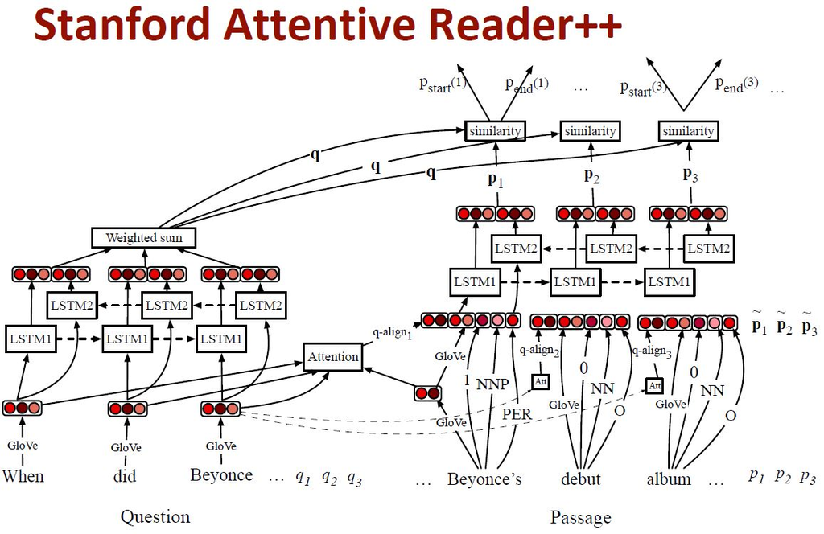

### 5.1 Model Classes

All the Attention classes are implemented as per mentioned in above.Here with list of all classes implemented.

1. Embedding - For embedding layer
2. BiLSTM - For bi-directional LSTM
3. Attention - weighted sum
4. Aligned Question Embedding
5. Bilinear Similarity
6. Prediction

```python
from tensorflow.keras.layers import Bidirectional,LSTM,Dense,Dropout,BatchNormalization,Flatten,Input
from tensorflow.keras.models import Model
from tensorflow.keras.layers import concatenate
```

#### 5.1.1 Embedding - For embedding layer

```python
class Embedding(tf.keras.Model):
    """
    This class applies embedding layer to given input.

    """
    def __init__(self, vocab_size,embedding_matrix , embedding_dim = 300):

        super(Embedding,self).__init__()

        self.embedding = tf.keras.layers.Embedding(vocab_size, embedding_dim,weights=[embedding_matrix],trainable=False,mask_zero=True)

    def call(self, x):

        x = self.embedding(x)
        return x
```

#### 5.1.2 BiLSTM - For bi-directional LSTM

```python
class BiLSTM(tf.keras.Model):
    """
    This class is for bidirectional LSTM we are going to use.
    """

    def __init__(self,num_units):

        super(BiLSTM, self).__init__()

        self.num_units = num_units
        self.bilstm = Bidirectional(LSTM(num_units,return_sequences=True,recurrent_initializer='glorot_uniform',dropout = 0.3))

    def call(self,x):

        output = self.bilstm(x)
        return output
```

#### 5.1.3 Attention - Weighted Context Vector

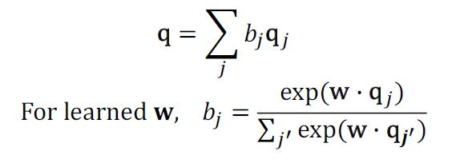

```python
class Attention(tf.keras.Model):

    """
    This class implements a weighted sum attention.

    """
    def __init__(self, units = 1):

        super(Attention, self).__init__()
        self.W = tf.keras.layers.Dense(units)

    def call(self, values):

        # values is the output of encoder. shape of values (batch,max_len,units)
        #score shape will be (batch,max_len,1)
        score = self.W(values)

        # attention_weights shape == (batch_size, max_length, 1)
        attention_weights = tf.nn.softmax(score, axis=1)

        # context_vector shape after sum == (batch_size, hidden_size)
        # for clear understanding please check broadcasting in numpy
        context_vector = attention_weights * values
        context_vector = tf.reduce_sum(context_vector, axis=1)

        return context_vector, attention_weights
```

#### 5.1.4 Aligned question Embedding

Alpha is a single dense layer with ReLU nonlinearity.

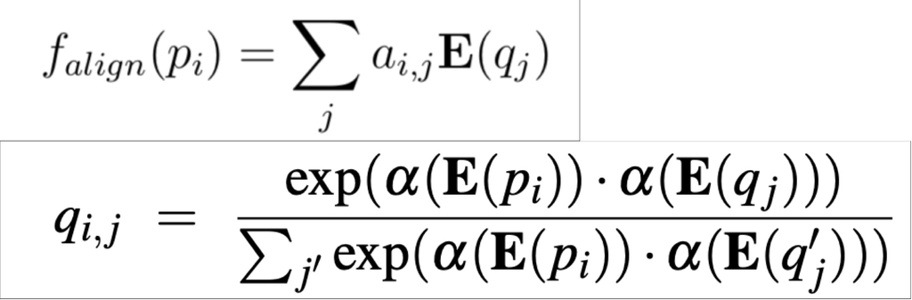

```python
class AlignAttention(tf.keras.Model):

    """
    This class implements ths aligned question embedding as mentioned in paper.
    For better understanding please check the concept of broadcasting.
    @ returns : (batch_size,decoder_timesteps,encoder_units)

    """

    def __init__(self, units = 1):

        super(AlignAttention, self).__init__()

        self.W1 = tf.keras.layers.Dense(units,activation="relu")
        self.W2 = tf.keras.layers.Dense(units,activation="relu")

    def call(self,encoder,decoder):

        # shape of encoder is (batch_size,encoder_timesteps,encoder_units)
        # shape of decoder (batch_size,decoder_timesteps,decoder_units)

        # check for efficient way to transform (64,30,128)) * (64,150,128) ==> (64,150,128)

        temporal_tensor = []

        for i in range(decoder.shape[1]):
            # for every time slice (64,i,128)
            query = decoder[:,i,:]

            # shape (64,128) --> (64,1,128)
            hidden_with_time_axis = tf.expand_dims(query, 1)

            # score shape == (batch_size, max_length, 1)
            score = self.W1(encoder) * self.W2(hidden_with_time_axis)
            # attention_weights shape == (batch_size, max_length, 1)
            attention_weights = tf.nn.softmax(score, axis=1)

            context_vector = attention_weights * encoder
            # context_vector shape after sum == (batch_size, hidden_size)
            context_vector = tf.reduce_sum(context_vector, axis=1)

            temporal_tensor.append(tf.expand_dims(context_vector,axis = 1))
            #batch_,hidden_ = context_vector.shape
            #temporal_tensor.append(tf.reshape(context_vector,(batch_,-1,hidden_)))

        # concate all tensor along temporal axis.
        # return shape should be (batch,decoder_timestep,hidden)
        q_align = tf.concat(temporal_tensor,axis = 1)

        return tf.concat([q_align,decoder],axis = 2)
```

```python
# uncomment to test the layer.

# # test code
# in_ = Input(shape=(30,300),batch_size=64)
# en = LSTM(128,return_sequences=True)(in_)
# print(en.shape)

# # test code
# in_ = Input(shape=(100,300),batch_size=64)
# de = LSTM(128,return_sequences=True)(in_)
# print(de.shape)

# att = AlignAttention()(en,de)
# print(att.shape)
```

#### 5.1.5 Bilinear Term for probability calculations

we use a bilinear term to capture the similarity between pi and q and compute the probabilities of each token being start and end.

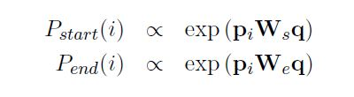

```python
class BilinearSimilarity(tf.keras.Model):
    """
    This function calcualtes biliear term used for answer span prediction.
    Referance took from --> https://github.com/kellywzhang/reading-comprehension/blob/master/attention.py

    """

    def __init__(self,hidden_size):

        super(BilinearSimilarity,self).__init__()

        self.units = hidden_size * 2
        self.WS = tf.keras.layers.Dense(self.units)
        self.WE = tf.keras.layers.Dense(self.units)


    def call(self,query,values):

        # quesry corresponds to final question context vector (batch_size,hidden)
        # values are output of decoder i.e context (batch_size,decoder_timesteps,hidden)

        # taking transpose of values (0,1,2) --> (0,2,1)

        #values = tf.transpose(values,[0,2,1])



        ################ start prediction ######################
        start = self.WS(query)

        # ading time_slice to question (batch_size,1,hidden)
        # shape (64,128) --> (64,1,128)
        hidden_start_time_axis = tf.expand_dims(start, -1)

        # squeeze remooves time slice we added before
        # final shape = (batch_size,decoder_timesteps)
        start_ = tf.squeeze(tf.matmul(values,hidden_start_time_axis),-1)

        start_ = tf.nn.softmax(start_,axis = 1)

        ################ end prediction ######################
        end = self.WE(query)

        hidden_end_time_axis = tf.expand_dims(end, -1)

        # squeeze remooves time slice we added before
        # final shape = (batch_size,decoder_timesteps)
        end_ = tf.squeeze(tf.matmul(values,hidden_end_time_axis),-1)
        end_ = tf.nn.softmax(end_,axis=1)

        prob = tf.concat((start_,end_),axis = 1)

        return prob


# this class is beacause we are using custom loss function.
# so need start and end logits. Which is used during calculation of loss.

class BilinearSimilarityLogits(tf.keras.Model):
    """
    This class is for calculating start and end logits.
    Referance took from --> https://github.com/kellywzhang/reading-comprehension/blob/master/attention.py

    """

    def __init__(self,hidden_size):

        super(BilinearSimilarityLogits,self).__init__()

        self.units = hidden_size * 2
        self.WS = tf.keras.layers.Dense(self.units)
        self.WE = tf.keras.layers.Dense(self.units)


    def call(self,query,values):

        # quesry corresponds to final question context vector (batch_size,hidden)
        # values are output of decoder i.e context (batch_size,decoder_timesteps,hidden)

        # taking transpose of values (0,1,2) --> (0,2,1)

        values = tf.transpose(values,[0,2,1])



        ################ start prediction ######################
        start = self.WS(query)

        # ading time_slice to question (batch_size,1,hidden)
        # shape (64,128) --> (64,1,128)
        hidden_start_time_axis = tf.expand_dims(start, 1)

        # squeeze remooves time slice we added before
        # final shape = (batch_size,decoder_timesteps)

        start_logit = tf.squeeze(tf.matmul(hidden_start_time_axis,values),axis=1)

        #start_ = tf.nn.softmax(start_,axis = 1)

        ################ end prediction ######################
        end = self.WE(query)

        hidden_end_time_axis = tf.expand_dims(end, 1)

        # squeeze remooves time slice we added before
        # final shape = (batch_size,decoder_timesteps)
        end_logit = tf.squeeze(tf.matmul(hidden_end_time_axis,values),axis=1)
        #end_ = tf.nn.softmax(end_,axis=1)

        # shape is (batch_size,2* timesteps)
        logits = tf.concat([start_logit,end_logit],axis=1)
        return logits
```

```python
# uncomemnt code to test the layer.

# # test code
# from tensorflow.keras.layers import Dense,Input
# q = Input(shape=(256,),batch_size=64)
# v = Input(shape=(400,256),batch_size=64)
# bln = BilinearSimilarityLogits(128)(q,v)
# bln
```

#### 5.1.6 Predict

During prediction, we choose the best span from token i to token i' such that i <= i' <= i + 15 and Pstart(i) * Pend(i0) is maximized.

Please refer https://hanxiao.github.io/2018/04/21/Teach-Machine-to-Comprehend-Text-and-Answer-Question-with-Tensorflow/

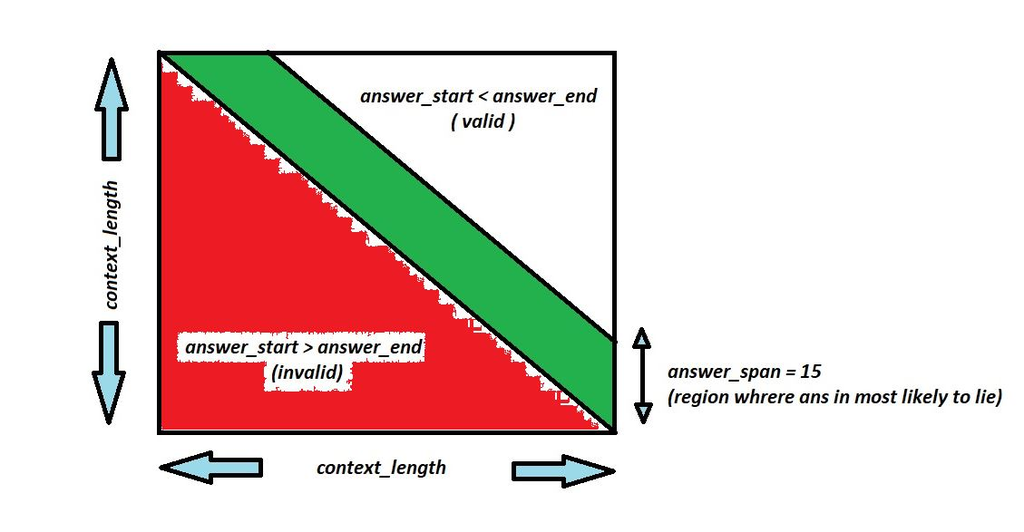

#### 5.1.6 Prediction class

```python
# remeber to use softmax before prediction is using input from class BilinearSimilarityLogits. As we are getting logits.
# Need to aaply softmax layer.

class Prediction(tf.keras.Model):
    """
    This class predicts probabilities of start and end token.
    Took referance from https://hanxiao.github.io/2018/04/21/Teach-Machine-to-Comprehend-Text-and-Answer-Question-with-Tensorflow/

    """
    def __init__(self,token_span = 15):

        super(Prediction,self).__init__()
        self.token_span = token_span

    def call(self,prob):

        #assert start_prob.shape == end_prob.shape , "Please check probabilities shape"


        start_prob = prob[:,:CON_LEN]
        end_prob = prob[:,CON_LEN:]

        # do the outer product
        outer = tf.matmul(tf.expand_dims(start_prob, axis=2),tf.expand_dims(end_prob, axis=1))

        outer = tf.matrix_band_part(outer, 0, self.token_span)

        #print(outer.shape)

        # start_position will have shape of (batch_size,)
        start_position = tf.reduce_max(outer, axis=2)
        #end position will have shape of (batch_size,)
        end_position = tf.reduce_max(outer, axis=1)

        probab = tf.concat([start_position,end_position],axis=1)
        return probab

        # masking start and end position to get y_pred as [0,0,0,1,1,1,0,...]
        # sequence mask will convert to 2D tensor of shape (batch_size,timesteps)

        #s_ = tf.sequence_mask(start_position,self.timesteps,dtype=tf.int32)
        #e_ = tf.sequence_mask(end_position,self.timesteps,dtype= tf.int32)

        # to get answers from start to end subtract 1 from start_position.
        #s_ = s_ - 1



        # subtract end_postion from start_positions to get in form of array
        # final shape should be (batch_size,timesteps)
        #return tf.subtract(e_,s_)
```

#### 5.1.7 Custom Loss Function

```python
def logits_loss(y_true,logits):
    """
    Custom loss function which minimises log_loss.
    Referance https://stackoverflow.com/questions/50063613/add-loss-function-in-keras
    """

    #y_true = tf.cast(y_true,dtype=tf.int32)
    #logits = tf.cast(logits,dtype=tf.float32)

    # breaking the tensor into two half's to get start and end label.
    start_label = y_true[:,:CON_LEN]
    end_label = y_true[:,CON_LEN:]

    # braking the logits tensor into start and end part for loss calcultion.
    start_logit = logits[:,:CON_LEN]
    end_logit = logits[:,CON_LEN:]

    start_loss = tf.keras.backend.categorical_crossentropy(start_label,start_logit)
    end_loss = tf.keras.backend.categorical_crossentropy(end_label,end_logit)

#     start_loss = tf.losses.sparse_softmax_cross_entropy(labels=start_label, logits=start_logit)
#     end_loss = tf.losses.sparse_softmax_cross_entropy(labels=end_label, logits=end_logit)

    # as per paer

    loss = start_loss + end_loss

    return loss
```

### 5.2 Building Model

```python
UNITS = 64
```

```python
# model building...

# question embedding
q_input = Input(shape=(QUES_LEN,))
q_emb = Embedding(VOCAB_SIZE,embedding_matrix)(q_input)

# encoder
q_cont = BiLSTM(UNITS)(q_emb)

# question context
q_cont,_ = Attention()(q_cont)
print(q_cont.shape)
```

[output not shown]

```python
# context side model

# try to improve AlignAttention performance.
c_input = Input(shape=(CON_LEN,))

# context embedding
c_emb = Embedding(VOCAB_SIZE,embedding_matrix)(c_input)



# exact_match
ex_ = Input(shape=(CON_LEN,2))

# pos tags
pos_ = Input(shape=(CON_LEN,len(tag_to_num)+1))

# term frequency
term_ = Input(shape=(CON_LEN,1))

# concatenate input
concat = concatenate([c_emb,ex_,pos_,term_])

c_ = BiLSTM(UNITS)(concat)

print("final output that is fed to bilinear ",c_.shape)
```

```
final output that is fed to bilinear  (?, 680, 128)
```

```python
# bilinear term
print("Question context shape ",q_cont.shape)
print("final o/p of context ",c_.shape)

logits = BilinearSimilarity(UNITS)(q_cont,c_)
Y_prob = Prediction()(logits)
print("Logits shape ",logits.shape)
```

```
Question context shape  (?, 128)
final o/p of context  (?, 680, 128)
Logits shape  (?, 1360)
```

```python
model = Model(inputs = [q_input,c_input,ex_,pos_,term_],outputs =Y_prob)
model.summary()
```

```
__________________________________________________________________________________________________
Layer (type)                    Output Shape         Param #     Connected to
==================================================================================================
input_1 (InputLayer)            (None, 40)           0
__________________________________________________________________________________________________
input_19 (InputLayer)           (None, 680)          0
__________________________________________________________________________________________________
embedding (Embedding)           (None, 40, 300)      22386300    input_1[0][0]
__________________________________________________________________________________________________
embedding_10 (Embedding)        (None, 680, 300)     22386300    input_19[0][0]
__________________________________________________________________________________________________
input_20 (InputLayer)           (None, 680, 2)       0
__________________________________________________________________________________________________
input_21 (InputLayer)           (None, 680, 37)      0
__________________________________________________________________________________________________
input_22 (InputLayer)           (None, 680, 1)       0
__________________________________________________________________________________________________
bi_lstm (BiLSTM)                (None, 40, 128)      186880      embedding[0][0]
__________________________________________________________________________________________________
concatenate_4 (Concatenate)     (None, 680, 340)     0           embedding_10[0][0]
                                                                 input_20[0][0]
                                                                 input_21[0][0]
                                                                 input_22[0][0]
__________________________________________________________________________________________________
attention (Attention)           [(None, 128), (None, 129         bi_lstm[0][0]
__________________________________________________________________________________________________
bi_lstm_2 (BiLSTM)              (None, 680, 128)     207360      concatenate_4[0][0]
__________________________________________________________________________________________________
bilinear_similarity_3 (Bilinear (None, 1360)         33024       attention[0][0]
                                                                 bi_lstm_2[0][0]
__________________________________________________________________________________________________
prediction_4 (Prediction)       (None, 1360)         0           bilinear_similarity_3[0][0]
==================================================================================================
Total params: 45,199,993
Trainable params: 427,393
Non-trainable params: 44,772,600
__________________________________________________________________________________________________
```

#### 5.2.1 Generator Function for Data

```python
from numpy import array
def generator_function(length,batch_size = 64,data_type = 'Train'):
    """
    This function is generates batches of data to avoid strain on memory.
    """
    X1, X2,X3,X4,X5, y = list(), list(), list(),list(), list(), list()
    flag = True
    if data_type == 'Val':
        flag = False
    n = 0
    # loop forever over datapoints.
    while 1:
        for i in range(length):
            n += 1
            if flag:
                X1.append(train_question_sequence[i])
                X2.append(train_context_sequence[i])
                X3.append(train_excat_lemma[i])
                X4.append(train_pos_tag[i])
                X5.append(train_term[i])
                y.append(y_train[i])
            else:
                X1.append(cv_question_sequence[i])
                X2.append(cv_context_sequence[i])
                X3.append(cv_excat_lemma[i])
                X4.append(cv_pos_tag[i])
                X5.append(cv_term[i])
                y.append(y_cv[i])
            if n== batch_size:
                yield ((array(X1),array(X2),array(X3),array(X4),array(X5)),array(y))
                X1, X2,X3,X4,X5 ,y = list(), list(), list(),list(), list(), list()
                n=0
```

```python
# https://datascience.stackexchange.com/questions/35775/how-to-find-auc-metric-value-for-keras-model
from sklearn import metrics
from keras import backend as K
from sklearn.metrics import roc_auc_score

# https://stackoverflow.com/questions/41032551/how-to-compute-receiving-operating-characteristic-roc-and-auc-in-keras
```

```python
# using tensorboard instance for callbacks
from time import time
from datetime import datetime
from tensorflow.python.keras.callbacks import TensorBoard

tensorboard = TensorBoard(log_dir="logs_123/{}".format(time()))

# model compilation
model.compile(optimizer="adamax",loss=logits_loss,metrics=['acc'])
```

```python
epochs = 25
batch_size = 64
train_length = len(y_train)
cv_length = len(y_cv)
train_steps = train_length//batch_size
cv_steps = cv_length//32
```

```python
# checkpointer = tf.keras.callbacks.ModelCheckpoint(filepath='model/weights.{epoch:02d}-{val_loss:.2f}.hdf5', verbose=1,save_best_only=True)
# history = tf.keras.callbacks.History()
from keras_tqdm import TQDMNotebookCallback
```

```python
# # keras, model definition...
# cb = TQDMNotebookCallback()
# setattr(cb,'on_train_batch_begin',lambda x,y:None)
# setattr(cb,'on_train_batch_end',lambda x,y:None)
```

```python
for i in range(epochs):
    print("Epoch {} start at time ".format(i),datetime.now())
    generator = generator_function(train_length,batch_size)
    cv_generator = generator_function(cv_length,32,"cv")
    model.fit_generator(generator, epochs=1, steps_per_epoch=train_steps,verbose=0,callbacks=[tensorboard],validation_data=cv_generator,validation_steps=cv_steps)
    model.save_weights("model_epoch_{}.h5".format(i))
```

```
Epoch 0 start at time  2019-08-03 23:44:38.683862
Epoch 1 start at time  2019-08-04 00:37:12.239359
Epoch 2 start at time  2019-08-04 01:29:02.412844
Epoch 3 start at time  2019-08-04 02:21:03.556801
Epoch 4 start at time  2019-08-04 03:13:08.305536
Epoch 5 start at time  2019-08-04 04:05:50.085794
Epoch 6 start at time  2019-08-04 04:57:43.108128
Epoch 7 start at time  2019-08-04 05:50:02.592364
Epoch 8 start at time  2019-08-04 06:42:03.231385
Epoch 9 start at time  2019-08-04 07:34:00.938980
Epoch 10 start at time  2019-08-04 08:25:50.587550
Epoch 11 start at time  2019-08-04 09:18:41.804714
Epoch 12 start at time  2019-08-04 10:11:19.028138
Epoch 13 start at time  2019-08-04 11:05:33.530653
Epoch 14 start at time  2019-08-04 11:57:27.985265
Epoch 15 start at time  2019-08-04 12:52:02.470259
Epoch 16 start at time  2019-08-04 13:44:30.796746
Epoch 17 start at time  2019-08-04 14:37:38.830766
```

[output not shown]

**Epoch Vs Validation Loss**

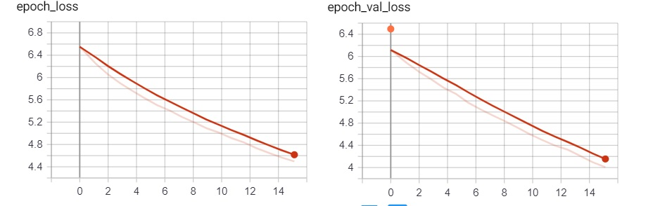

**Epoch And Validation Accuracy***

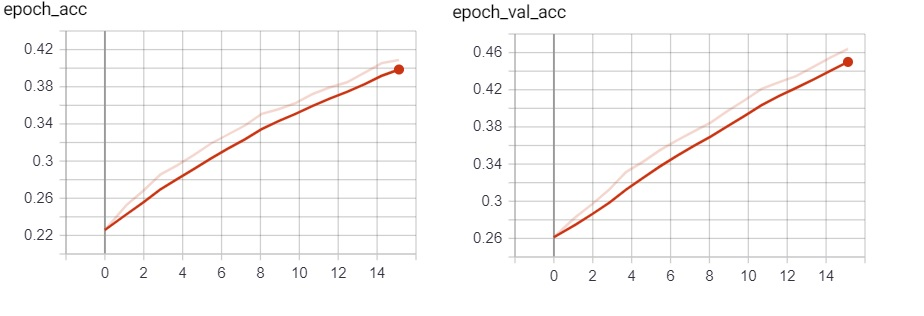